# Data Visualization - Part 2

The Good, The Bad and The Ugly

Scott Stoltzman

March 14, 2017

# Data Visualization - Part 2

## A Quick Overview of the ggplot2 Package in R

While it will be important to focus on theory, I want to explain the ggplot2 package because I will be using it throughout the rest of this series. It’s an incredibly powerful package and once you wrap your head around what it’s doing, your life will change for the better! There are a lot of tools out there which provide better charts, graphs and ease of use (i.e. plot.ly, d3.js, Qlik, Tableau), but ggplot2 is still a fantastic resource and I use it all of the time.

In case you missed it, here’s a link to [Data Visualization - Part 1](https://www.stoltzmaniac.com/data-visualization-part-1/)

[figure not shown]

### Why should you use ggplot2?

1. More robust plotting than the base plot package
2. Better control over aesthetics - colors, axes, background, etc.
3. Layering
4. Variable Mapping (aes)
5. Automatic aggregation of data
6. Built in formulas & plotting (geom_smooth)
7. The list goes on and on…

Basically, ggplot2 allows for a lot more customization of plots with a lot less code (the rest of it is behind the scenes). Once you are used to the syntax, there’s no going back. It’s faster and easier.

### Why wouldn’t you use ggplot2?

1. A bit of a learning curve
2. Lack of user interactivity with the plots

Fundamentally, ggplot2 gives the user the ability to start a plot and layer everything in. There are many ways to accomplish the same thing, so figure out what makes sense for you and stick to it.

**A Basic Example: Unemployment Over Time**

```r
library(dplyr)
library(ggplot2)

# Load the economics data from ggplot2
data(economics,package='ggplot2')
```

```r
# Take a look at the format of the data
head(economics)
```

```
## # A tibble: 6 × 6
##         date   pce    pop psavert uempmed unemploy
##       <date> <dbl>  <int>   <dbl>   <dbl>    <int>
## 1 1967-07-01 507.4 198712    12.5     4.5     2944
## 2 1967-08-01 510.5 198911    12.5     4.7     2945
## 3 1967-09-01 516.3 199113    11.7     4.6     2958
## 4 1967-10-01 512.9 199311    12.5     4.9     3143
## 5 1967-11-01 518.1 199498    12.5     4.7     3066
## 6 1967-12-01 525.8 199657    12.1     4.8     3018
```

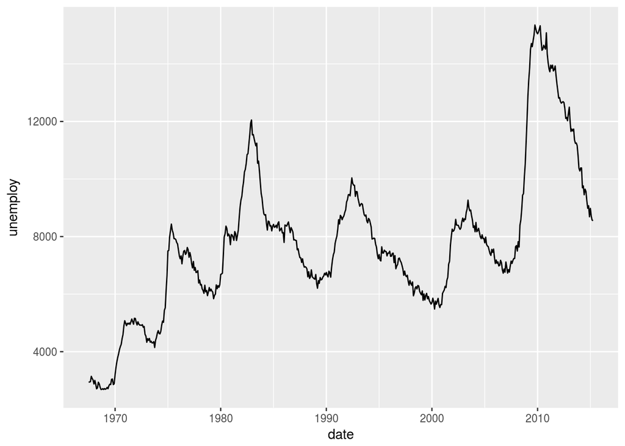

```r
# Create the plot
ggplot(data = economics) + geom_line(aes(x = date, y = unemploy))
```

### What happened to get that?

- `ggplot(economics)` loaded the data frame
- `+` tells ggplot() that there is more to be added to the plot
- `geom_line()` defined the type of plot
- `aes(x = date, y = unemploy)` mapped the variables

The `aes()` portion is what typically throws new users off but is my favorite feature of ggplot2. In simple terms, this is what “auto-magically” brings your plot to life. You are telling ggplot2, “I want ‘date’ to be on the x-axis and ‘unemploy’ to be on the y-axis.” It’s pretty straightforward in this case but there are more complex use cases as well.

*Side Note:* you could have achieved the same result by mapping the variables in the ggplot() function rather than in geom_line(): `ggplot(data = economics, aes(x = date, y = unemploy)) + geom_line()`

### Here’s the basic formula for success:

- Everything in ggplot2 starts with `ggplot(data)` and utilizes `+` to add on every element thereafter
- Include your data frame (economics) in a ggplot function: `ggplot(data = economics)`
- Input the type of plot you would like (i.e. line chart of unemployment over time): `+ geom_line(aes(x = date, y = unemploy))`
  - There are *a lot* of types of plots - check them out [here](http://docs.ggplot2.org/current/)
- Add in layers and utilize `fill` and `col` parameters within `aes()`

I’ll go through some of the examples from the [Top 50 ggplot2 Visualizations Master List](http://r-statistics.co/Top50-Ggplot2-Visualizations-MasterList-R-Code.html). I will be using their examples but I will also explain what’s going on.

**Note:** I believe the intention of the author of the [Top 50 ggplot2 Visualizations Master List](http://r-statistics.co/Top50-Ggplot2-Visualizations-MasterList-R-Code.html) was to illustrate how to use ggplot2 rather than doing a full demonstration of what important data visualization techniques are - so keep that in mind as I go through these examples. Some of the visuals do not line up with my best practices addressed in my [first post on data visualization](https://www.stoltzmaniac.com/data-visualization-part-1/).

As usual, some packages must be loaded.

```r
library(reshape2)
library(lubridate)
library(dplyr)
library(tidyr)
library(ggplot2)
library(scales)
library(gridExtra)
```

### The Scatterplot

This is one of the most visually powerful tool for data analysis. However, you have to be careful when using it because it’s primarily used by people doing analysis and not reporting (depending on what industry you’re in).

The author of this chart was looking for a correlation between area and population.

```r
# Use the "midwest"" data from ggplot2
data("midwest", package = "ggplot2")

head(midwest)
```

```
## # A tibble: 6 × 28
##     PID    county state  area poptotal popdensity popwhite popblack
##   <int>     <chr> <chr> <dbl>    <int>      <dbl>    <int>    <int>
## 1   561     ADAMS    IL 0.052    66090  1270.9615    63917     1702
## 2   562 ALEXANDER    IL 0.014    10626   759.0000     7054     3496
## 3   563      BOND    IL 0.022    14991   681.4091    14477      429
## 4   564     BOONE    IL 0.017    30806  1812.1176    29344      127
## 5   565     BROWN    IL 0.018     5836   324.2222     5264      547
## 6   566    BUREAU    IL 0.050    35688   713.7600    35157       50
## # ... with 20 more variables: popamerindian <int>, popasian <int>,
## #   popother <int>, percwhite <dbl>, percblack <dbl>, percamerindan <dbl>,
## #   percasian <dbl>, percother <dbl>, popadults <int>, perchsd <dbl>,
## #   percollege <dbl>, percprof <dbl>, poppovertyknown <int>,
## #   percpovertyknown <dbl>, percbelowpoverty <dbl>,
## #   percchildbelowpovert <dbl>, percadultpoverty <dbl>,
## #   percelderlypoverty <dbl>, inmetro <int>, category <chr>
```

#### Here’s the most basic version of the scatter plot

This can be called by `geom_point()` in ggplot2

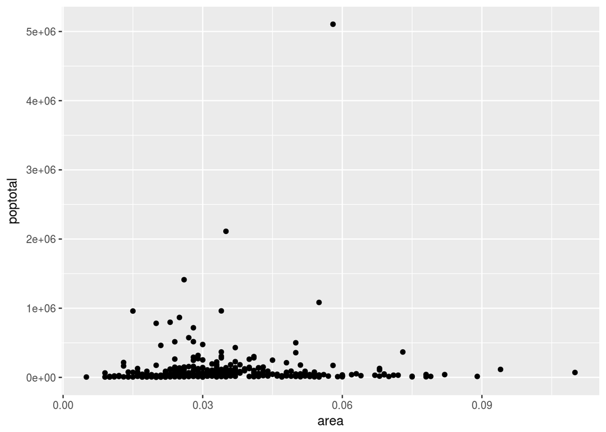

```r
# Scatterplot
ggplot(data = midwest, aes(x = area, y = poptotal)) + geom_point()  #ggplot
```

#### Here’s version with some additional features

While the addition of the size of the points and color don’t add value, it does show the level of customization that’s possible with ggplot2.

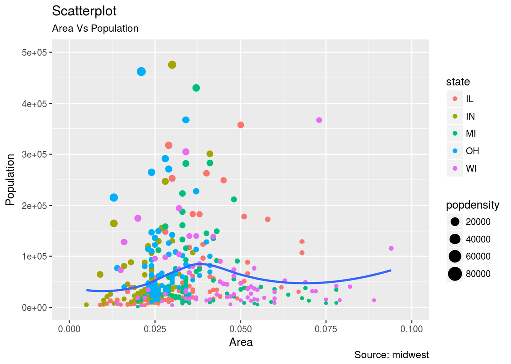

```r
ggplot(data = midwest, aes(x = area, y = poptotal)) +
geom_point(aes(col=state, size=popdensity)) +
  geom_smooth(method="loess", se=F) +
  xlim(c(0, 0.1)) +
  ylim(c(0, 500000)) +
  labs(subtitle="Area Vs Population",
       y="Population",
       x="Area",
       title="Scatterplot",
       caption = "Source: midwest")
```

```r
data(economics,package='ggplot2') # load the economics data
econ = melt(economics[, c("date", "pce", "unemploy", "psavert")], id="date")
df = econ %>%
  filter(variable == 'pce') %>%
  group_by(date) %>%
  summarise(pce = sum(value))
```

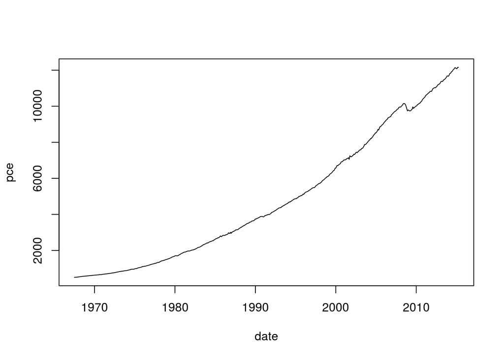

```r
plot(df,type='l')
```

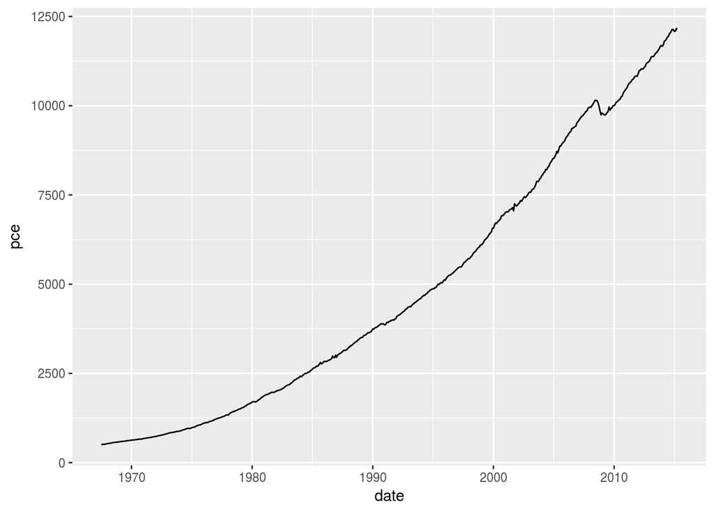

```r
p = ggplot(df, aes(x=date, y=pce, group=1))
p + geom_line() + scale_x_date()
```

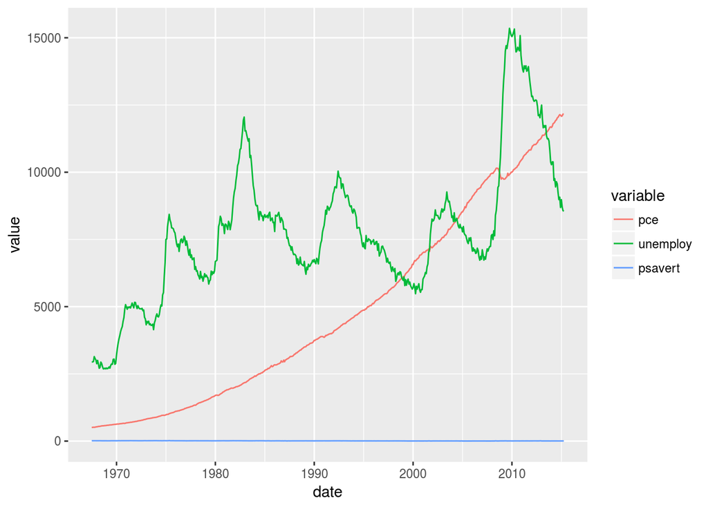

```r
p = ggplot(econ, aes(x=date))
p + geom_line(aes(y=value,col=variable))
```

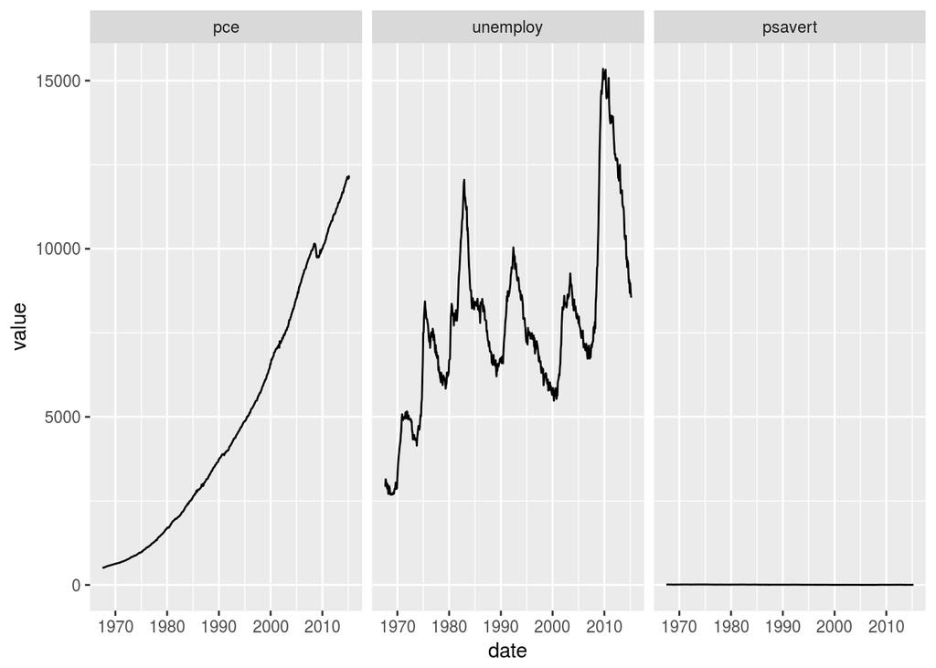

```r
p + geom_line(aes(y=value)) + facet_wrap(~variable)
```

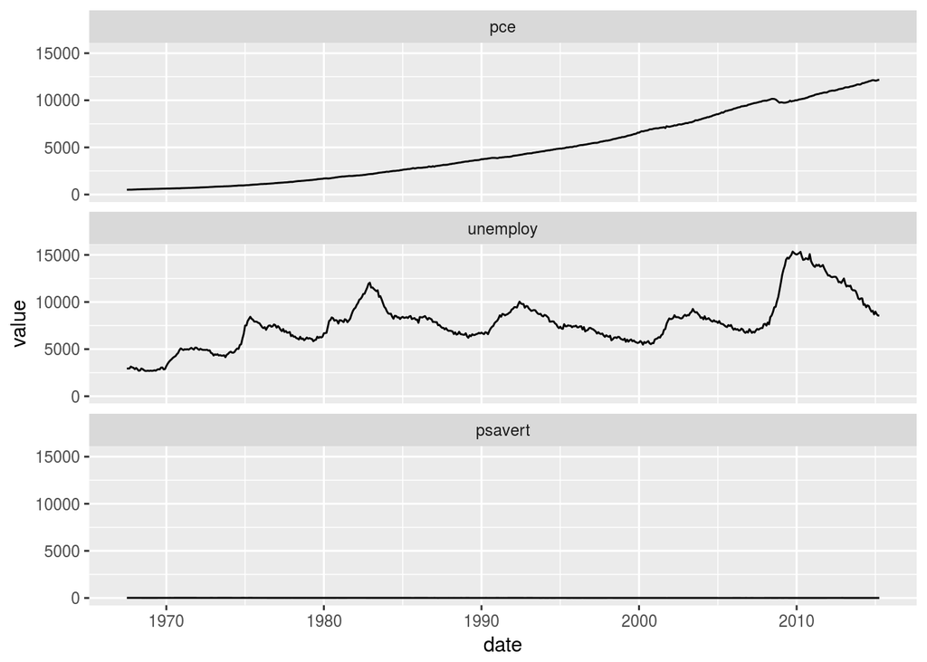

```r
p + geom_line(aes(y=value)) + facet_wrap(~variable,ncol=1)
```

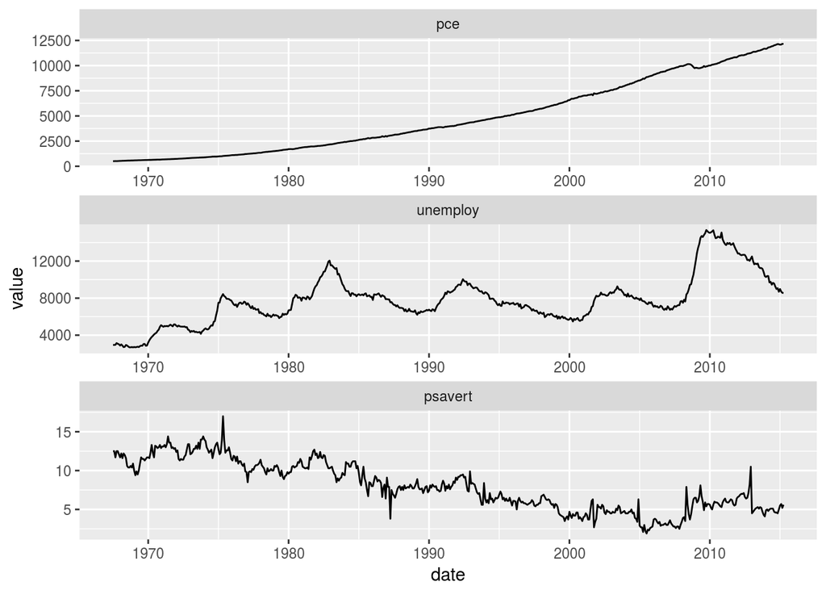

```r
p + geom_line(aes(y=value)) + facet_wrap(~variable,ncol=1,scales='free')
```

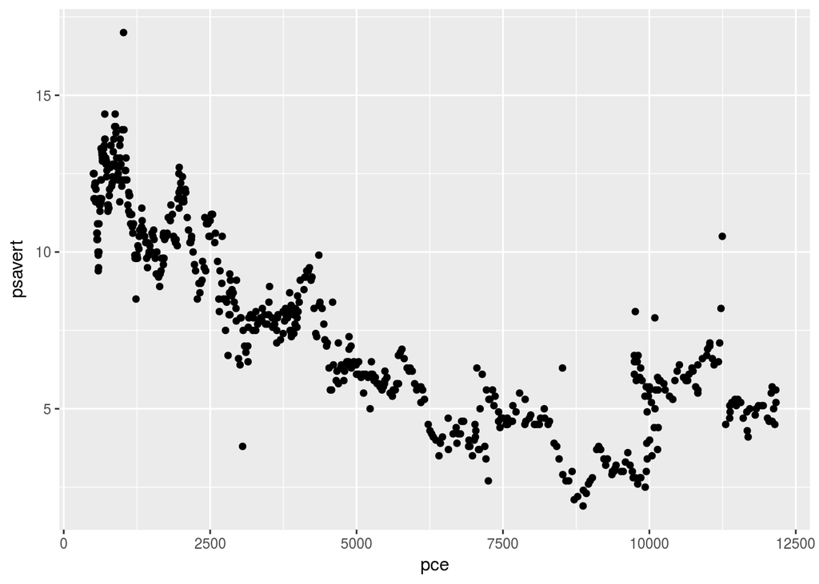

```r
df = econ %>%
  spread(variable,value)
p = ggplot(df)
p + geom_point(aes(x=pce,y=psavert))
```

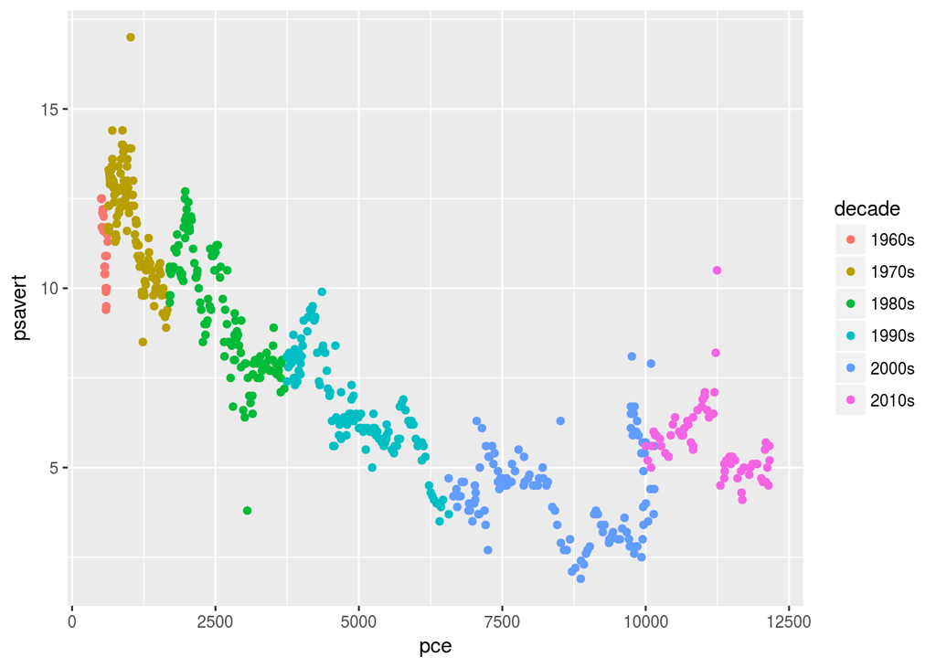

```r
econ$year = year(econ$date)
econ$decade = '1960s'
econ$decade[econ$year >= 1970] = '1970s'
econ$decade[econ$year >= 1980] = '1980s'
econ$decade[econ$year >= 1990] = '1990s'
econ$decade[econ$year >= 2000] = '2000s'
econ$decade[econ$year >= 2010] = '2010s'
econ$decade = as.factor(econ$decade)

df = econ %>%
  spread(variable,value)
p = ggplot(df)
p + geom_point(aes(x=pce,y=psavert,col=decade))
```

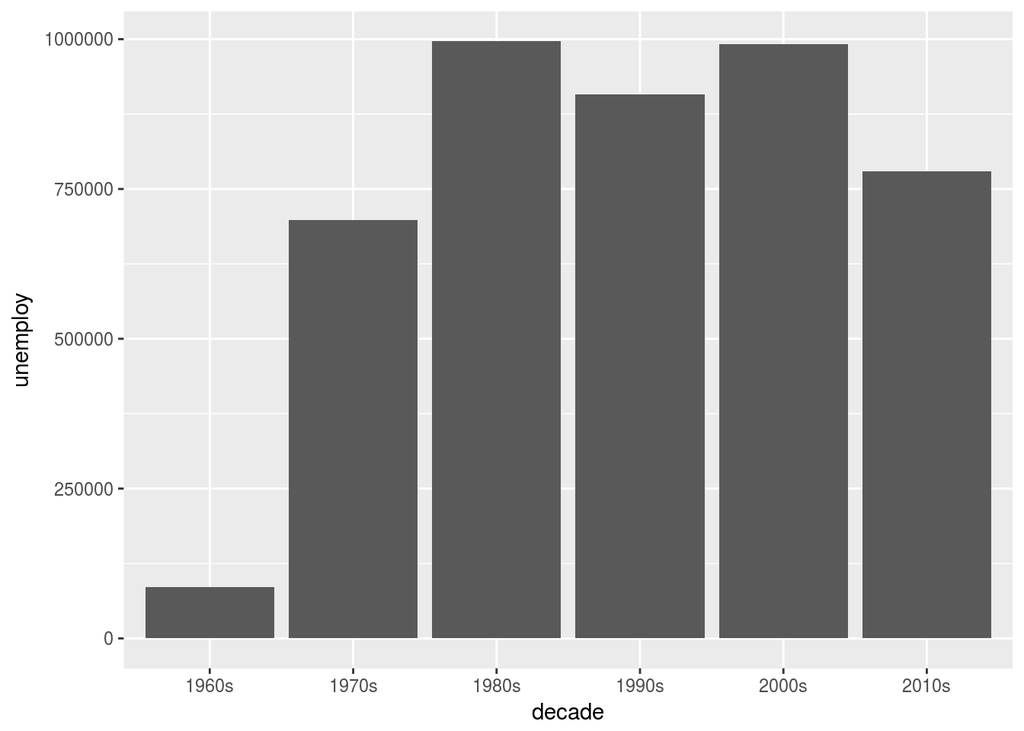

```r
p + geom_bar(aes(x=decade,y=unemploy),stat='identity')
```

As always, the code used in this post is on my [GitHub](https://github.com/stoltzmaniac/Data-Visualization-Lesson)